# Share price evolution of the 4 largest mining companies in South Africa (by market capitalization)

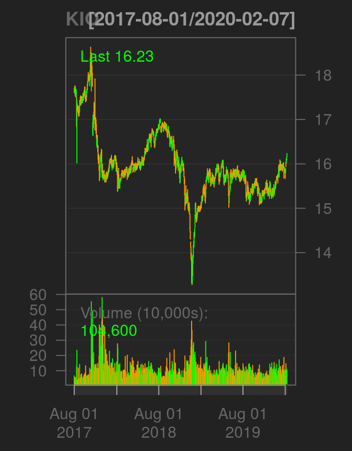

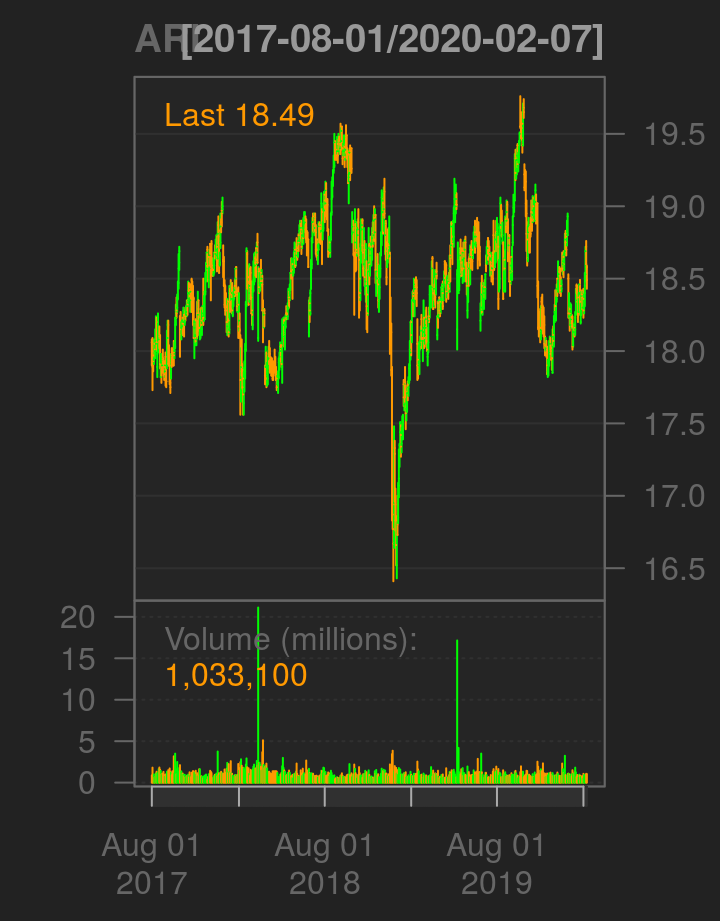

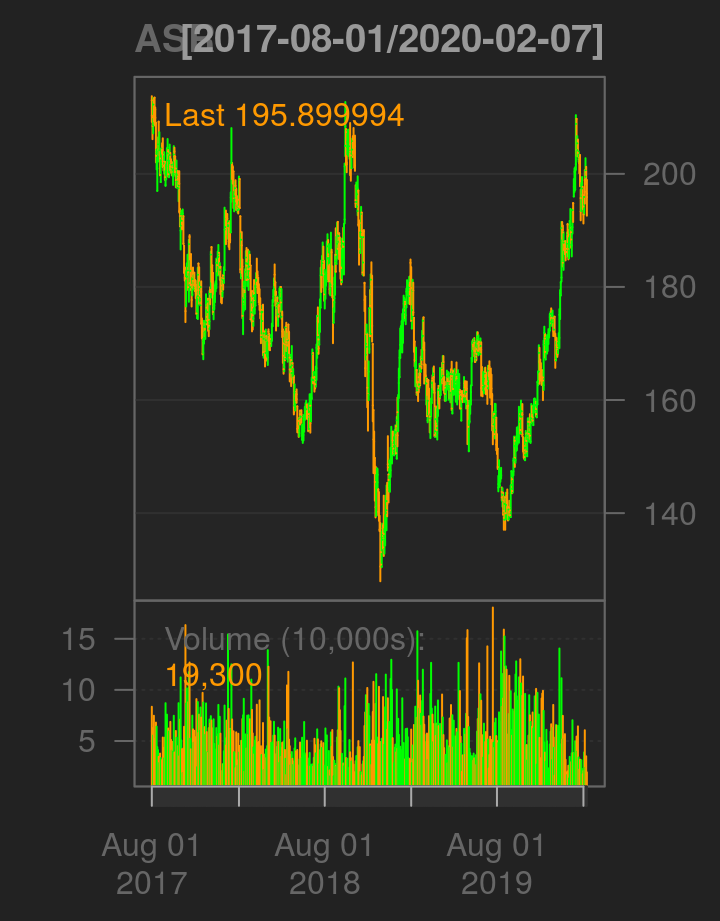

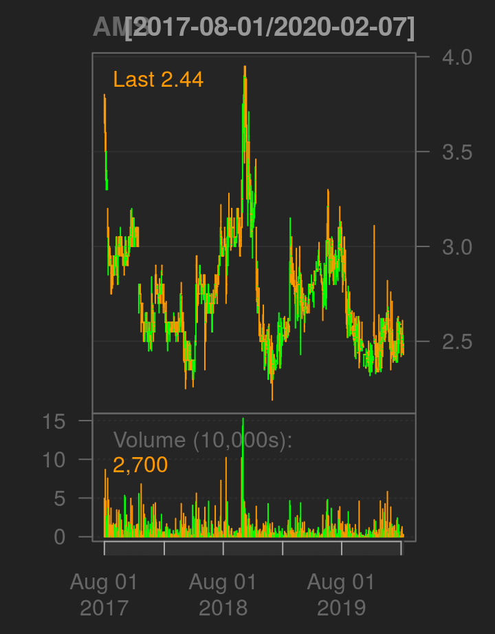

### **KUMBA IRON ORE LIMITED**

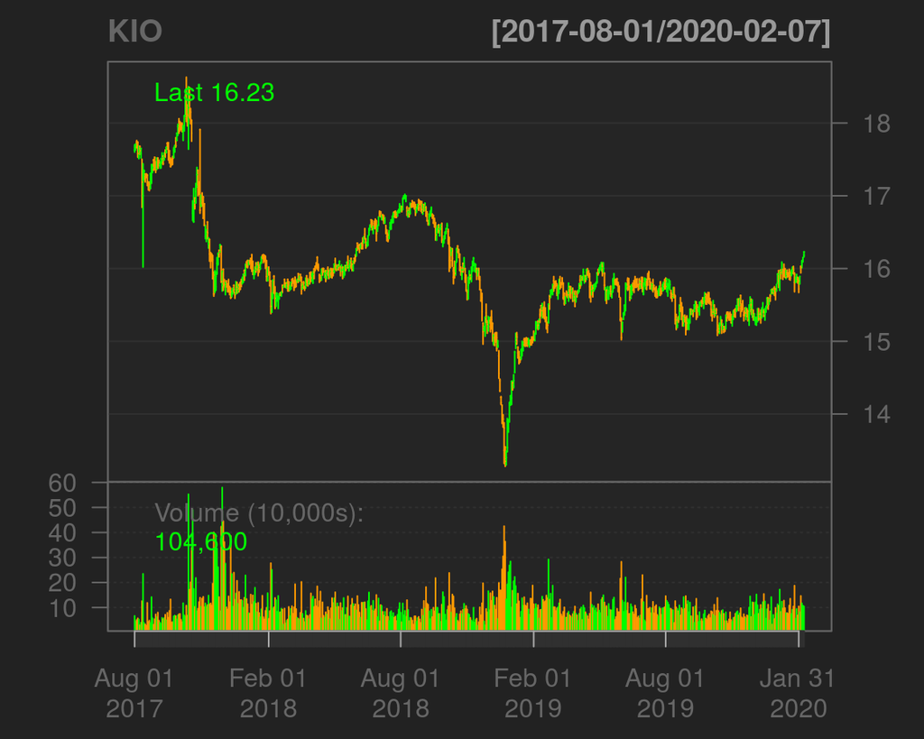

### **AFRICAN RAINBOW MINERALS LIMITED**

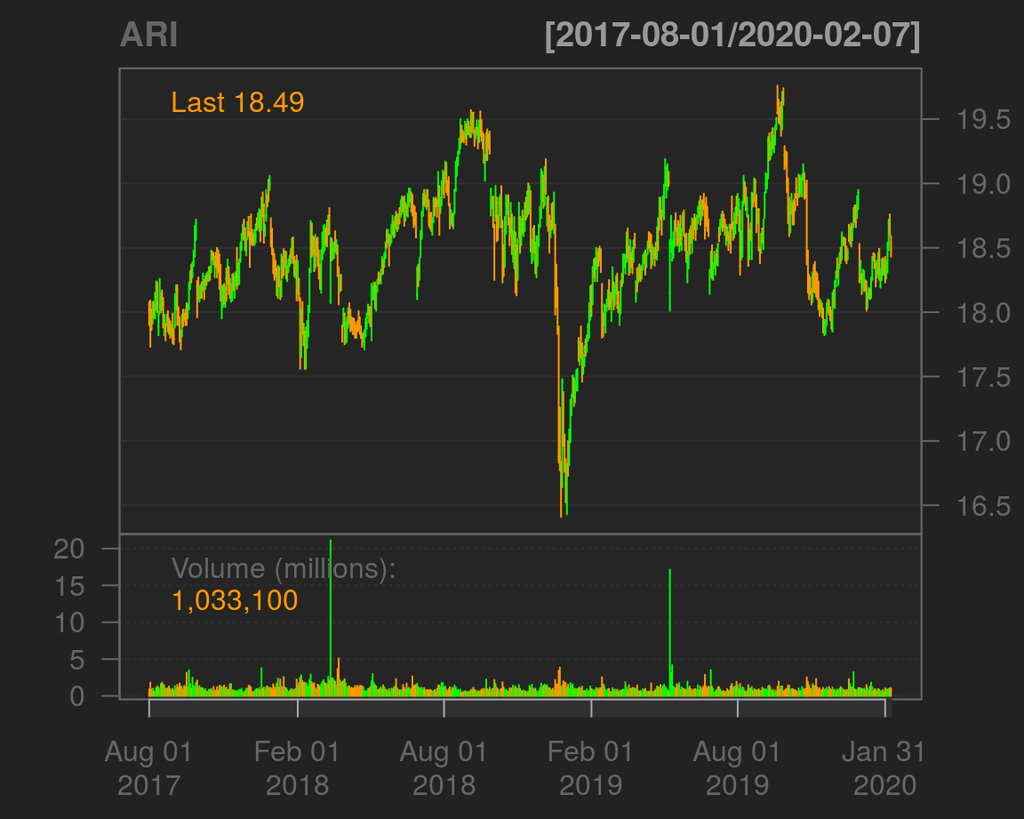

### **ASSORE LIMITED**

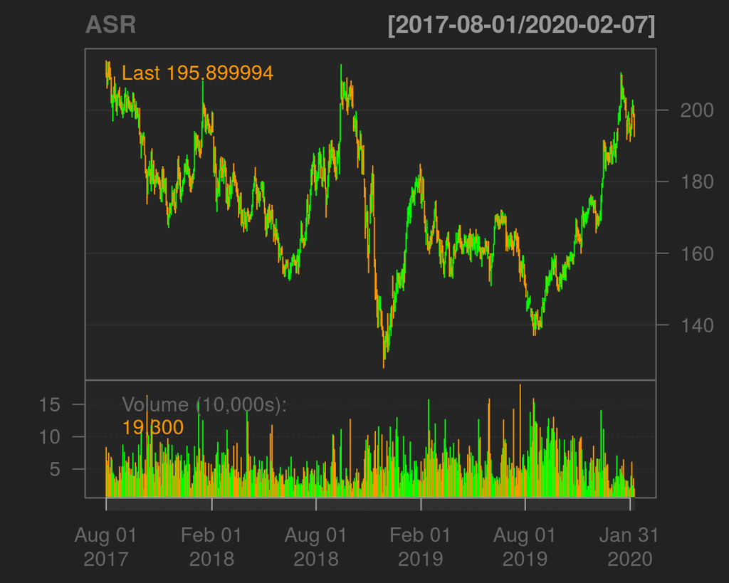

### **ANGLO AMERICAN PLATINUM LIMITED**

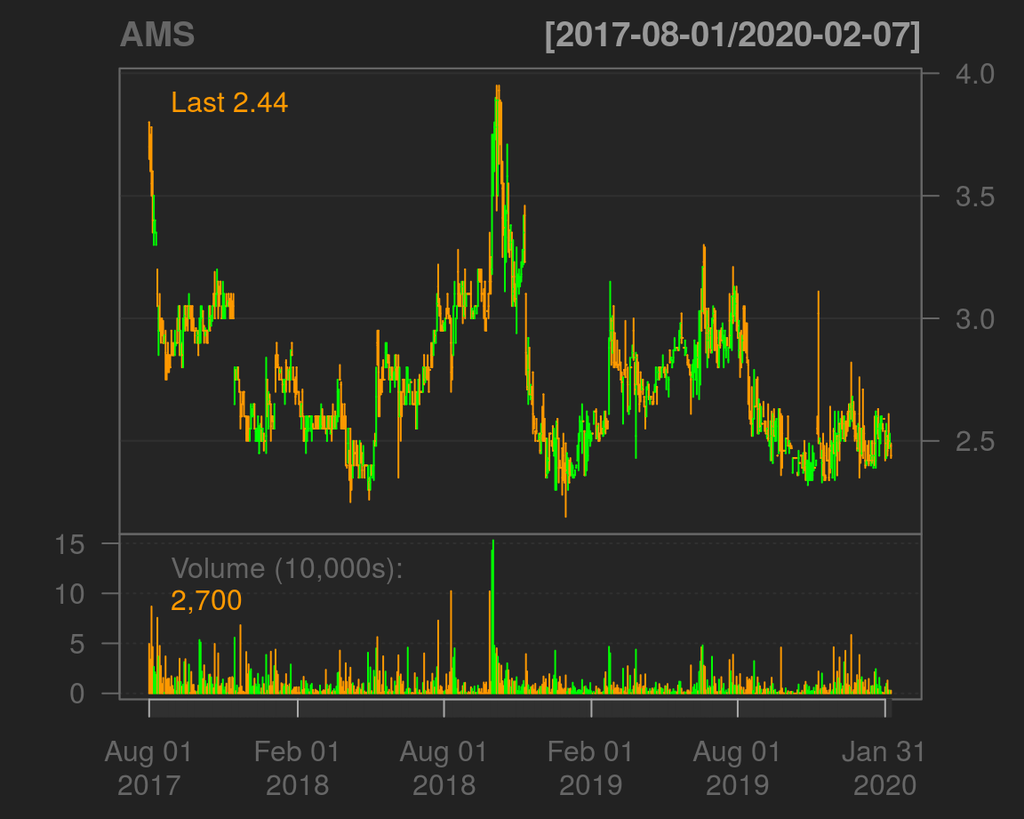

### **COMMENT**

On the left of this page, it has been made possible to compare the share price evolution of the 4 largest mining companies in South Africa (by market capitalization) :  
- KUMBA IRON ORE LIMITED  
- AFRICAN RAINBOW MINERALS LIMITED  
- ASSORE LIMITED  
- ANGLO AMERICAN PLATINUM LIMITED

The time period is from 2017-08-01 to today, it is the same for all the graphs to be able to compare them without scale difficulties. This way, by clicking on the different tabs, the graphics overlaps perfectly.

### **ANALYSE**

By comparing these different graphs, it is possible to highlight the dip in the middle of it. This shows a big drop in the valuation of South African mining companies at the end of 2018.

In fact, reading the news of this period, we can see that the world price of raw materials has fallen. South Africa has been particularly affected because of many factors. On the **political** and **social** aspects, the government has prevented the dismissal of employees in the mining sector and is in the process of increasing overall wages. On the **economical** aspect, there is a lack of investments in mines and decreasing soil resources are forcing mining companies to dig deeper and deeper.

Thus, we can see through these graphs **a risk for South Africa**, which is highly dependent on its mineral resources, which are both exhaustible and require large financial investments.